# statistics

*solution_03_central_limit_theorem/02_normal/10_bounds_from_twotailarea_v1*

[video (using z-table)](https://vimeo.com/531935144)

[video (using app)](https://vimeo.com/531935582): the [app](http://18.191.167.248:3838/nprob/)

First, draw a sketch. We can label the $C$ axis by adding integer multiples of 13 to 43. We know to shade the the outsides because values far from 43 satisfy the condition $\big|C-43\big|>d$ (regardless of the exact value of $d$). We don’t know exactly where to place the boundaries, but we know the two-tail area is 0.24.

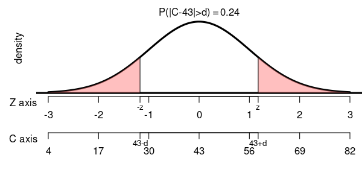

As an intermediate step, let’s find $z$ such that $P(|Z|>z)=0.24$. First, we need to evaluate $P(Z<z)$.

$$\begin{aligned}
P(Z<z) &= \frac{2-P(|Z|>z)}{2} \\ \\
&= \frac{2-0.24}{2} \\ \\
&= 0.88
\end{aligned}$$

You could have also drawn some pictures… we know there is symmetry and all the areas should add to 1.

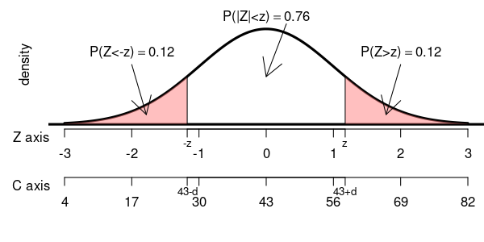

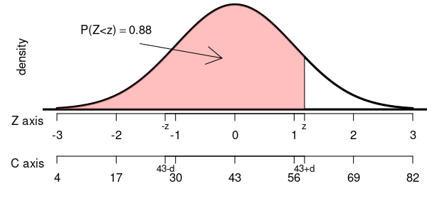

We find $z$ such that $P(Z<z)=0.88$.

By using the $z$ table we can determine $z$.

[output not shown]

Either 1.17 or 1.18 is a good estimation of $z$, and either value will lead you to an acceptable answer. Using other tools, a more accurate value can be found. I will show the work with a more accurate value.
$$z=1.175$$

We now convert the $z$ score into a $d$ score.
$$\begin{aligned}
d &= z\sigma \\
&= (1.175)(13) \\
&= 15.27
\end{aligned}$$

We can also visualize this with a spinner.

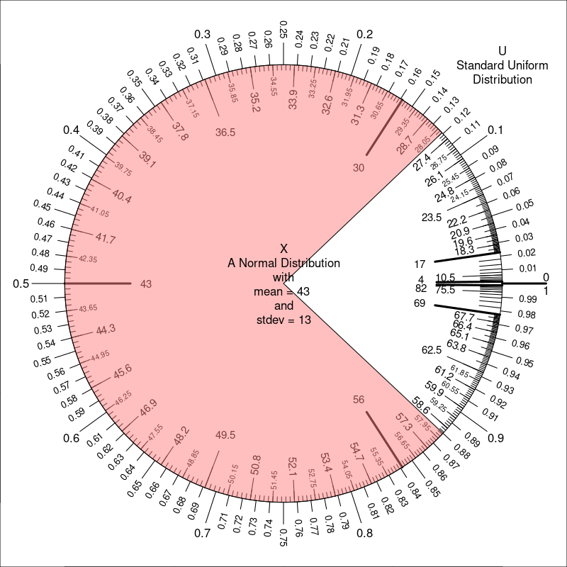

1. We determined $d=15.27$
2. It is easy to find $c_1 = 43-15.27 = 27.73$
3. It is easy to find $c_2 = 43+15.27 = 58.27$

ANSWERS: 15.2748283, 27.7251717, 58.2748283  
TOLERANCES: 1, 1, 1